# TSA Sheet 6

3. Create a purely random normally distributed time series realization with mean 0 and variance 1

```r
long <- rnorm(8192)
```

Plot the data with

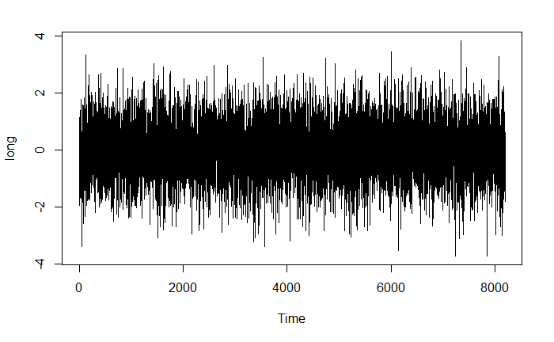

```r
ts.plot(long)
```

Compute and plot the raw periodogram

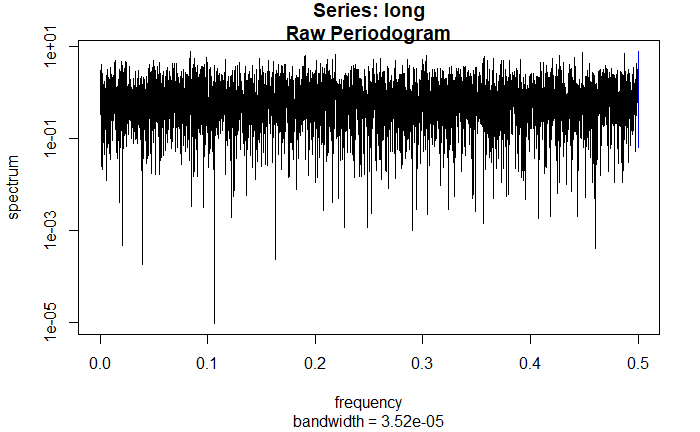

```r
rawp <- spec.pgram(long, taper = 0, detrend = FALSE,
plot = FALSE)
plot(rawp)
```

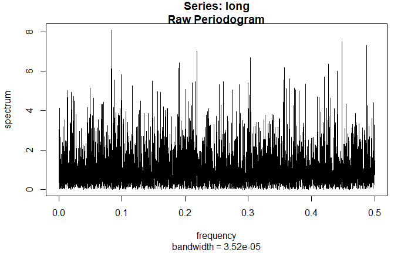

```r
plot(rawp, log="no")
```

In any case, both spectra look much too rough. R can smooth the spectra by using a technique called modified Daniell smoothing. In R the degree of smoothing is controlled by the spans argument to spec.pgram(). So try

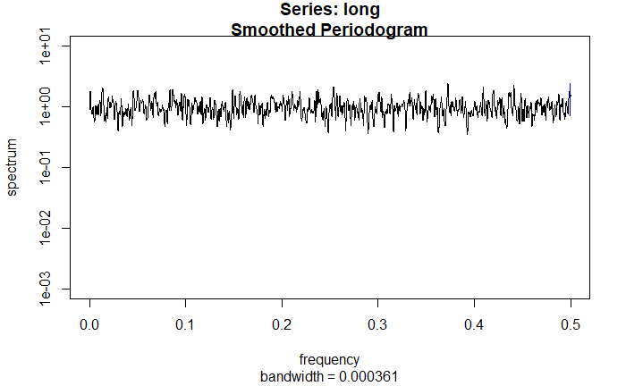

```r
smop <- spec.pgram(long, spans=c(9,7), taper = 0,
detrend = FALSE, plot = FALSE)
plot(smop, ylim=c(1e-3, 10))
```

4. Compute the log of the lynx data using

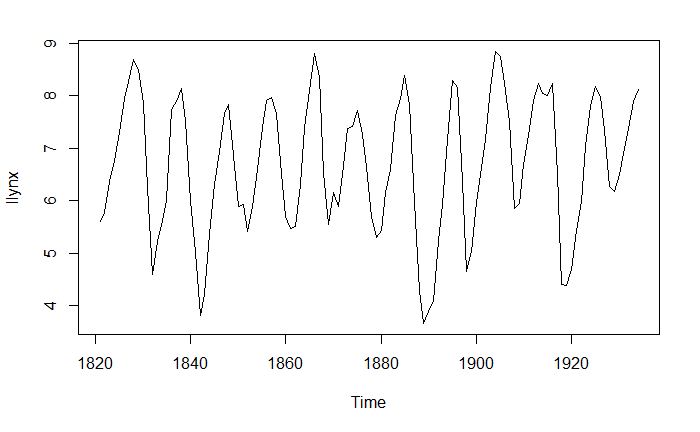

```r
llynx <- log(lynx)
ts.plot(llynx)
```

Guess what the period of the sinusoidal variation is - This appears to be around 10 years.

Compute the raw periodogram of the data (call it rawpl) and plot it. What do you see?

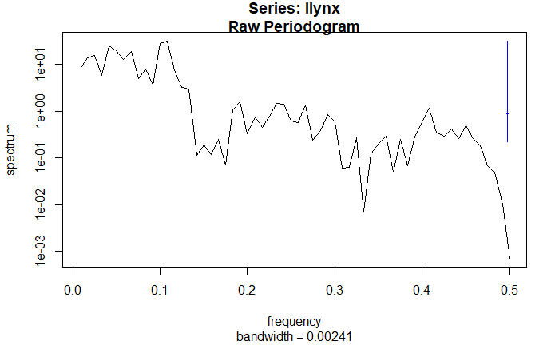

There should have been a peak at about 0.1. However, the raw periodogram is quite noisy so try the following two methods to smooth the periodogram: i. Use the spec.pgram() function with the spans=c(9,7) argument (as in the previous question).

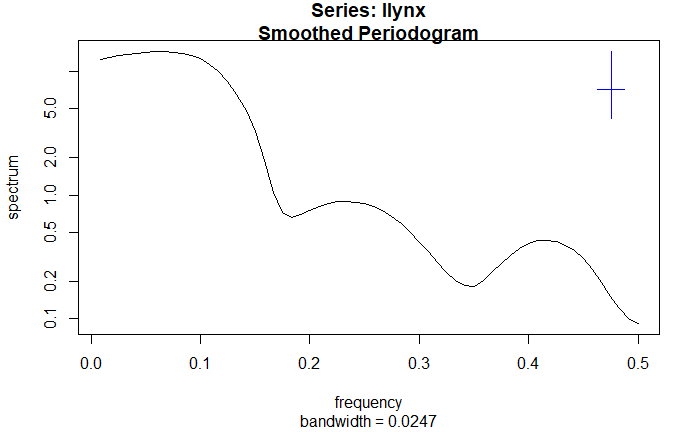

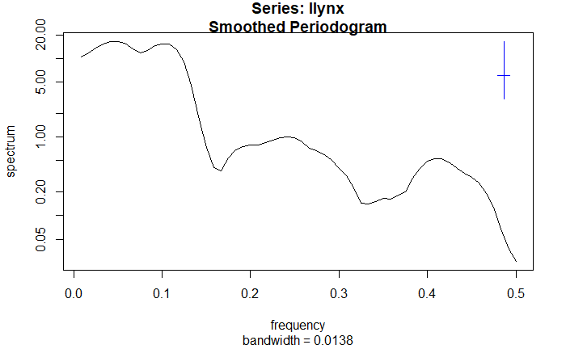

```r
smopl2 <- spec.pgram(llynx, kernel=kernel("daniell", c(1,2)),
taper = 0, detrend = FALSE, plot = FALSE)
plot(smopl2)
```

To find out more accurately where the largest peak is. Type > locator(1) after you have plotted the smoothed spectrum in either case and click the mouse at the maximum value on the graph. The x and y coordinates of where you clicked will be returned allowing you to identify the frequency where the periodogram maxed out

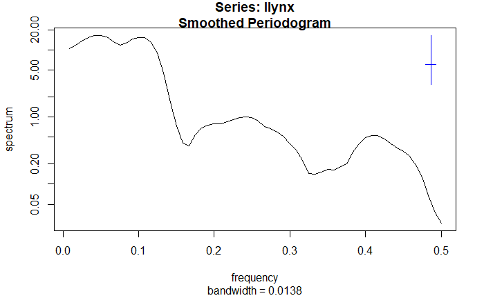

```r
smopl2 <- spec.pgram(llynx, kernel=kernel("daniell", c(1,2)),
taper = 0, detrend = FALSE, plot = FALSE)
plot(smopl2)
locator(1)
```

[output not shown]